# ExtraaLearn Project

## Context

The EdTech industry has been surging in the past decade immensely, and according to a forecast, the Online Education market would be worth $286.62bn by 2023 with a compound annual growth rate (CAGR) of 10.26% from 2018 to 2023. The modern era of online education has enforced a lot in its growth and expansion beyond any limit. Due to having many dominant features like ease of information sharing, personalized learning experience, transparency of assessment, etc, it is now preferable to traditional education.

In the present scenario due to the Covid-19, the online education sector has witnessed rapid growth and is attracting a lot of new customers. Due to this rapid growth, many new companies have emerged in this industry. With the availability and ease of use of digital marketing resources, companies can reach out to a wider audience with their offerings. The customers who show interest in these offerings are termed as leads. There are various sources of obtaining leads for Edtech companies, like

- The customer interacts with the marketing front on social media or other online platforms.
- The customer browses the website/app and downloads the brochure
- The customer connects through emails for more information.

The company then nurtures these leads and tries to convert them to paid customers. For this, the representative from the organization connects with the lead on call or through email to share further details.

## Objective

ExtraaLearn is an initial stage startup that offers programs on cutting-edge technologies to students and professionals to help them upskill/reskill. With a large number of leads being generated on a regular basis, one of the issues faced by ExtraaLearn is to identify which of the leads are more likely to convert so that they can allocate resources accordingly. You, as a data scientist at ExtraaLearn, have been provided the leads data to:

- Analyze and build an ML model to help identify which leads are more likely to convert to paid customers,
- Find the factors driving the lead conversion process
- Create a profile of the leads which are likely to convert

## Data Description

The data contains the different attributes of leads and their interaction details with ExtraaLearn. The detailed data dictionary is given below.

**Data Dictionary**

- ID: ID of the lead
- age: Age of the lead
- current_occupation: Current occupation of the lead. Values include 'Professional','Unemployed',and 'Student'
- first_interaction: How did the lead first interacted with ExtraaLearn. Values include 'Website', 'Mobile App'
- profile_completed: What percentage of profile has been filled by the lead on the website/mobile app. Values include Low - (0-50%), Medium - (50-75%), High (75-100%)
- website_visits: How many times has a lead visited the website
- time_spent_on_website: Total time spent on the website
- page_views_per_visit: Average number of pages on the website viewed during the visits.
- last_activity: Last interaction between the lead and ExtraaLearn.
  - Email Activity: Seeking for details about program through email, Representative shared information with lead like brochure of program , etc
  - Phone Activity: Had a Phone Conversation with representative, Had conversation over SMS with representative, etc
  - Website Activity: Interacted on live chat with representative, Updated profile on website, etc
- print_media_type1: Flag indicating whether the lead had seen the ad of ExtraaLearn in the Newspaper.
- print_media_type2: Flag indicating whether the lead had seen the ad of ExtraaLearn in the Magazine.
- digital_media: Flag indicating whether the lead had seen the ad of ExtraaLearn on the digital platforms.
- educational_channels: Flag indicating whether the lead had heard about ExtraaLearn in the education channels like online forums, discussion threads, educational websites, etc.
- referral: Flag indicating whether the lead had heard about ExtraaLearn through reference.
- status: Flag indicating whether the lead was converted to a paid customer or not.

The following notebook analyzes data from ExtraaLearn, an early-stage EdTech startup that offers cutting-edge technology programs to help students and professionals upskill/reskill. The main objective is to:

1. Build a machine learning model to identify leads more likely to convert to paid customers
2. Find factors driving the lead conversion process
3. Create a profile of leads likely to convert

## Importing necessary libraries and data

```python
import pandas as pd
import numpy as np
import matplotlib.pyplot as plt
import seaborn as sns
import math
from scipy import stats
from sklearn.model_selection import train_test_split, GridSearchCV
from sklearn.ensemble import RandomForestClassifier
from sklearn.tree import DecisionTreeClassifier
from sklearn.metrics import classification_report, confusion_matrix, accuracy_score, precision_score, recall_score
from sklearn.preprocessing import LabelEncoder
from sklearn import metrics
```

## Data Overview

- Observations
- Sanity checks

```python
from google.colab import drive
drive.mount('/content/drive/')

df = pd.read_csv('/content/drive/MyDrive/Colab Notebooks/ExtraaLearn.csv')

print("\nFirst 5 rows of the dataset:")
df.head()
```

```
First 5 rows of the dataset:
```

|  | ID | age | current_occupation | first_interaction | profile_completed | website_visits | time_spent_on_website | page_views_per_visit | last_activity | print_media_type1 | print_media_type2 | digital_media | educational_channels | referral | status |
| --- | --- | --- | --- | --- | --- | --- | --- | --- | --- | --- | --- | --- | --- | --- | --- |
| 0 | EXT001 | 57 | Unemployed | Website | High | 7 | 1639 | 1.861 | Website Activity | Yes | No | Yes | No | No | 1 |
| 1 | EXT002 | 56 | Professional | Mobile App | Medium | 2 | 83 | 0.320 | Website Activity | No | No | No | Yes | No | 0 |
| 2 | EXT003 | 52 | Professional | Website | Medium | 3 | 330 | 0.074 | Website Activity | No | No | Yes | No | No | 0 |
| 3 | EXT004 | 53 | Unemployed | Website | High | 4 | 464 | 2.057 | Website Activity | No | No | No | No | No | 1 |
| 4 | EXT005 | 23 | Student | Website | High | 4 | 600 | 16.914 | Email Activity | No | No | No | No | No | 0 |

```python
print("\nDataset Info:")
df.info()
```

```
Dataset Info:
<class 'pandas.core.frame.DataFrame'>
RangeIndex: 4612 entries, 0 to 4611
Data columns (total 15 columns):
 #   Column                 Non-Null Count  Dtype
---  ------                 --------------  -----
 0   ID                     4612 non-null   object
 1   age                    4612 non-null   int64
 2   current_occupation     4612 non-null   object
 3   first_interaction      4612 non-null   object
 4   profile_completed      4612 non-null   object
 5   website_visits         4612 non-null   int64
 6   time_spent_on_website  4612 non-null   int64
 7   page_views_per_visit   4612 non-null   float64
 8   last_activity          4612 non-null   object
 9   print_media_type1      4612 non-null   object
 10  print_media_type2      4612 non-null   object
 11  digital_media          4612 non-null   object
 12  educational_channels   4612 non-null   object
 13  referral               4612 non-null   object
 14  status                 4612 non-null   int64
dtypes: float64(1), int64(4), object(10)
memory usage: 540.6+ KB
```

```python
print("\nMissing Values:")
df.isnull().sum()
```

```
Missing Values:
```

|  | 0 |
| --- | --- |
| ID | 0 |
| age | 0 |
| current_occupation | 0 |
| first_interaction | 0 |
| profile_completed | 0 |
| website_visits | 0 |
| time_spent_on_website | 0 |
| page_views_per_visit | 0 |
| last_activity | 0 |
| print_media_type1 | 0 |
| print_media_type2 | 0 |
| digital_media | 0 |
| educational_channels | 0 |
| referral | 0 |
| status | 0 |

**dtype:** int64

```python
print("\nUnique Values:")
df.nunique()
```

```
Unique Values:
```

|  | 0 |
| --- | --- |
| ID | 4612 |
| age | 46 |
| current_occupation | 3 |
| first_interaction | 2 |
| profile_completed | 3 |
| website_visits | 27 |
| time_spent_on_website | 1623 |
| page_views_per_visit | 2414 |
| last_activity | 3 |
| print_media_type1 | 2 |
| print_media_type2 | 2 |
| digital_media | 2 |
| educational_channels | 2 |
| referral | 2 |
| status | 2 |

**dtype:** int64

#### Observation:

- The datasets comprises of 4612 rows and 15 columns.
- All columns have 4612 non-null entries meaning that there are no missing values in the dataset.
- ID is a unique identifier and therefore can be dropped for the purpose of this project as it will not add any value.
- Many columns only consist of 2 or 3 unique values, meaning they are likely categorical in nature. If they are also binary (i.e. Yes/No or True/ False), they will also require numerical manipulation prioir to model training.
- The numerical and categorical columns need to be separated for (1) different processing requirements and (2) different visual exploration.

```python
# Dropping unique identifier ID from DataFrame
df = df.drop(['ID'], axis=1)
```

```python
# Separation of numeric and categorical variables
numeric_cols = [col for col in df.select_dtypes(include=[np.number]).columns if col != 'status']
categorical_cols = [col for col in df.select_dtypes(exclude=[np.number]).columns]

print("Numeric Variables: "+str(numeric_cols))
print("Categorical Variables: "+str(categorical_cols))
```

```
Numeric Variables: ['age', 'website_visits', 'time_spent_on_website', 'page_views_per_visit']
Categorical Variables: ['current_occupation', 'first_interaction', 'profile_completed', 'last_activity', 'print_media_type1', 'print_media_type2', 'digital_media', 'educational_channels', 'referral']
```

## Exploratory Data Analysis (EDA)

- EDA is an important part of any project involving data.
- It is important to investigate and understand the data better before building a model with it.
- A few questions have been mentioned below which will help you approach the analysis in the right manner and generate insights from the data.
- A thorough analysis of the data, in addition to the questions mentioned below, should be done.

**Questions**

1. Leads will have different expectations from the outcome of the course and the current occupation may play a key role in getting them to participate in the program. Find out how current occupation affects lead status.
2. The company's first impression on the customer must have an impact. Do the first channels of interaction have an impact on the lead status?
3. The company uses multiple modes to interact with prospects. Which way of interaction works best?
4. The company gets leads from various channels such as print media, digital media, referrals, etc. Which of these channels have the highest lead conversion rate?
5. People browsing the website or mobile application are generally required to create a profile by sharing their personal data before they can access additional information.Does having more details about a prospect increase the chances of conversion?

### Univariate Data Analysis

```python
print("\nSummary Statistics:")
df[numeric_cols].describe().T
```

```
Summary Statistics:
```

|  | count | mean | std | min | 25% | 50% | 75% | max |
| --- | --- | --- | --- | --- | --- | --- | --- | --- |
| age | 4612.0 | 46.201214 | 13.161454 | 18.0 | 36.00000 | 51.000 | 57.00000 | 63.000 |
| website_visits | 4612.0 | 3.566782 | 2.829134 | 0.0 | 2.00000 | 3.000 | 5.00000 | 30.000 |
| time_spent_on_website | 4612.0 | 724.011275 | 743.828683 | 0.0 | 148.75000 | 376.000 | 1336.75000 | 2537.000 |
| page_views_per_visit | 4612.0 | 3.026126 | 1.968125 | 0.0 | 2.07775 | 2.792 | 3.75625 | 18.434 |

#### Observation:

- The average age of a potential client is 46.20 years old, but the ages range from 18-63 years of age. The median of the age of 51 suggests a slightly left- skewed distribution. The interquartile range (36-57) indicates most users are middle-aged to older adults.
- On average a person will visit the website 3.57 times. A standard deviation of 2.83, indicates moderate variability. 75% of users visit 5 or fewer times, with some more active users visiting up to 30 times.
- The average time spent on the website is 724.01 seconds (around 12 minutes). The high standard deviation of 743.83 indicates extreme variability in engagement. The median of 376 is much lower than the mean, indicating a right-skewed distribution. The large gap between the 75th percentile (1336.75) and the maximum (2537) suggests some extreme outliers.
- The average page views per visit is 3.03. The median of 2.79 is close to the mean, suggesting a fairly symmetric distribution. With 75% of visits involving fewer than 3.76 page views.

```python
# Function for conversion of variable names to visualisation display names
def get_display_name(column):
    # Replace underscores with spaces and capitalize each word
    return ' '.join(word.capitalize() for word in column.split('_'))
```

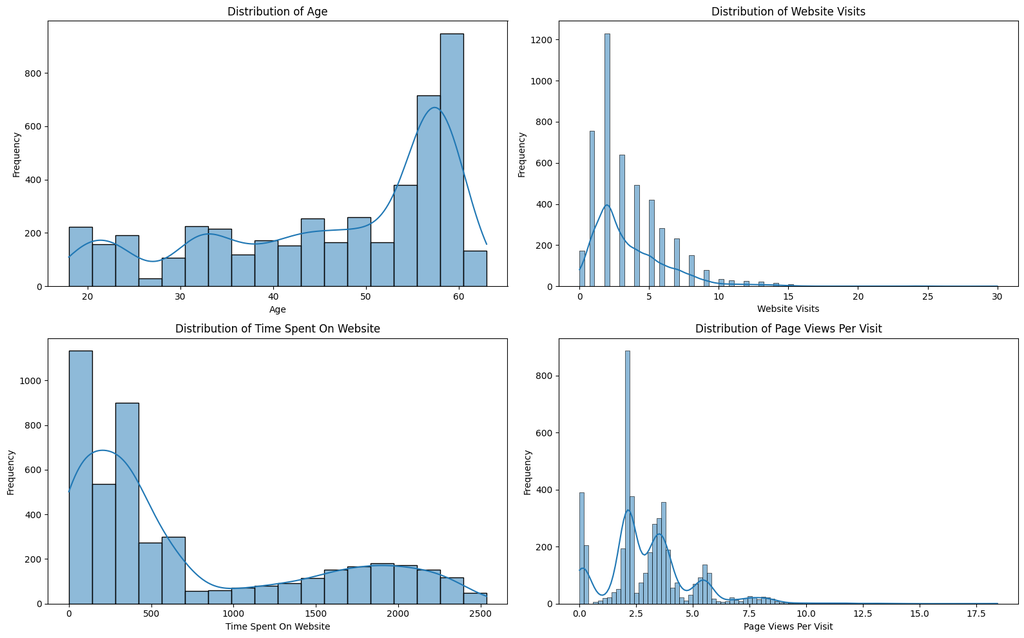

```python
def plot_numeric_histograms(df, numeric_cols, figsize=(16, 5*math.ceil(len(numeric_cols)/2))):
    """
    Create histograms for numeric columns arranged in subplots.
    Uses clean display names for titles and labels.
    """
    # Calculate layout dimensions
    n_plots = len(numeric_cols)
    n_cols = 2  # Show 2 plots per row
    n_rows = math.ceil(n_plots / n_cols)

    # Create the figure and subplots
    fig, axes = plt.subplots(n_rows, n_cols, figsize=figsize)
    axes = axes.flatten() if n_rows * n_cols > 1 else [axes]  # Flatten if multiple plots

    # Create a histogram for each numeric column
    for i, col in enumerate(numeric_cols):
        if i < len(axes):  # Ensure we don't exceed the number of subplots
            # Get the clean display name
            display_name = get_display_name(col)

            # Plot histogram with KDE
            sns.histplot(df[col], kde=True, ax=axes[i])
            axes[i].set_title(f'Distribution of {display_name}')
            axes[i].set_xlabel(display_name)
            axes[i].set_ylabel('Frequency')

    # Hide any unused subplots
    for j in range(i+1, len(axes)):
        axes[j].set_visible(False)

    plt.subplots_adjust(wspace=0.3, hspace=0.4)
    plt.tight_layout()
    plt.show()

plot_numeric_histograms(df, numeric_cols)
```

#### Observation:

1. **Age Distribution**:
   - The distribution is multimodal with the strongest peak at around 60 years.
   - The age distribution skews older, with the highest frequency in the 55-60 range.
   - There appears to be almost an even spread across age groups from 20-50, then a sharp increase.
2. **Website Visits Distribution**:
   - Extremely right-skewed distribution (follows a typical count/Poisson-like distribution)
   - Most users visit the website only 1-3 times (highest peak at 2 visits)
   - Frequency drops off dramatically after 5 visits
   - Very few users visit more than 10 times
3. **Time Spent on Website Distribution**:
   - Bimodal distribution with two distinct user behaviors: (1) a large group that spends very little time (0-500) and (2) a smaller but significant group spending 1500-2500.
   - The distribution has a "valley" in the middle (around 750-1000).
   - This suggests two distinct user types: brief visitors and highly engaged users.
4. **Page Views Per Visit Distribution**:
   - Complex multimodal distribution with peaks at approximately: 0 pages, 2.5 pages, 4-5 pages and 7 pages.
   - The pattern suggests different types of user engagement behaviors with most users view between 2-5 pages per visit.

These distributions reveal much more complexity than the summary statistics alone. They show distinct user segments and behavior patterns that wouldn't be apparent from looking at means and medians. The multimodal nature of several distributions suggests different user types with varying engagement patterns, which could be valuable for targeted marketing or UX improvements.

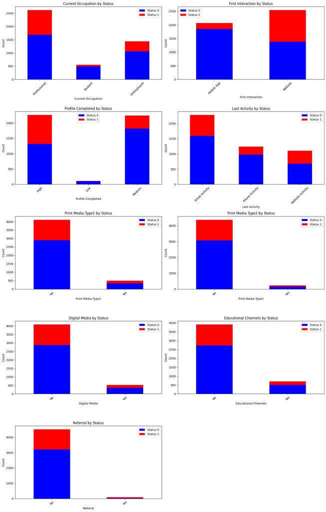

```python
def plot_categorical_bars(df, categorical_cols, figsize=(16, 5*math.ceil(len(categorical_cols)/2))):
    """
    Create stacked bar charts for categorical columns arranged in subplots.
    Uses clean display names for titles and labels.
    """
    # Calculate layout dimensions
    n_plots = len(categorical_cols)
    n_cols = 2  # Show 2 plots per row
    n_rows = math.ceil(n_plots / n_cols)

    # Create the figure and subplots
    fig, axes = plt.subplots(n_rows, n_cols, figsize=figsize)
    axes = axes.flatten() if n_rows * n_cols > 1 else [axes]  # Flatten if multiple plots

    # Create a stacked bar chart for each categorical column
    for i, col in enumerate(categorical_cols):
        if i < len(axes):  # Ensure we don't exceed the number of subplots
            # Get the clean display name
            display_name = get_display_name(col)

            # Create cross-tabulation
            crosstab = pd.crosstab(df[col], df['status'])

            # Plot stacked bar chart
            crosstab.plot(kind='bar', stacked=True, ax=axes[i], color=['blue', 'red'])
            axes[i].set_title(f'{display_name} by Status')
            axes[i].set_xlabel(display_name)
            axes[i].set_ylabel('Count')
            axes[i].tick_params(axis='x', rotation=45)
            axes[i].legend(['Status 0', 'Status 1'])

    # Hide any unused subplots
    for j in range(i+1, len(axes)):
        axes[j].set_visible(False)

    plt.subplots_adjust(wspace=0.3, hspace=0.4)
    plt.tight_layout()
    plt.show()

plot_categorical_bars(df, categorical_cols)
```

#### Observation:

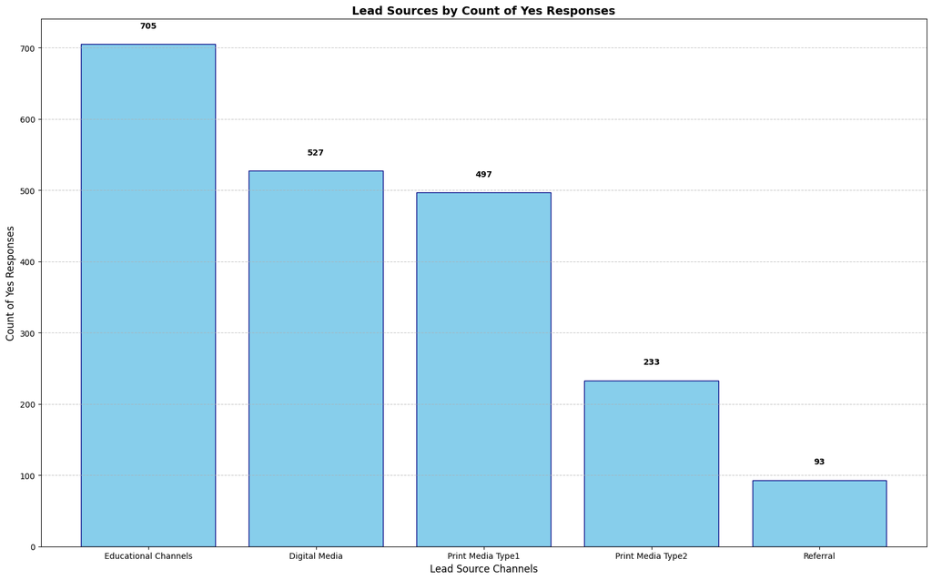

```python
def plot_lead_sources_yes_count(df, lead_source_cols, figsize=(16, 10)):
    """
    Create a simple bar chart showing the count of 'Yes' responses for each lead source channel.
    Uses clean display names for better readability.
    """
    # Create figure and axis
    fig, ax = plt.subplots(figsize=figsize)

    # Create a list to store data for plotting
    display_names = []
    yes_counts = []

    # Process each lead source column
    for col in lead_source_cols:
        # Count only "Yes" responses
        count = df[df[col] == "Yes"].shape[0]
        # Get display name
        display_name = get_display_name(col)
        # Append to lists
        display_names.append(display_name)
        yes_counts.append(count)

    # Create a DataFrame for easier sorting
    data_df = pd.DataFrame({'Channel': display_names, 'Count': yes_counts})
    data_df = data_df.sort_values('Count', ascending=False)

    # Plot bars
    bars = ax.bar(data_df['Channel'], data_df['Count'], color='skyblue', edgecolor='navy')

    # Add count labels on top of bars
    for bar in bars:
        height = bar.get_height()
        ax.text(bar.get_x() + bar.get_width()/2., height + 20,
                f'{int(height)}', ha='center', va='bottom', fontweight='bold')

    # Set labels and title
    ax.set_xlabel('Lead Source Channels', fontsize=12)
    ax.set_ylabel('Count of Yes Responses', fontsize=12)
    ax.set_title('Lead Sources by Count of Yes Responses', fontsize=14, fontweight='bold')

    # Add grid lines for better readability
    ax.grid(axis='y', linestyle='--', alpha=0.7)

    # Adjust layout
    plt.tight_layout()
    plt.show()

# Call the function with your lead source columns
lead_source_cols = ['print_media_type1', 'print_media_type2', 'digital_media', 'educational_channels', 'referral']
plot_lead_sources_yes_count(df, lead_source_cols)
```

#### Observation:

Educational Channels generate the highest volume of leads (705), followed by Digital Media (527) and Print Media Type1 (497). There's a significant drop to Print Media Type2 (233) and Referrals (93). The data reveals a heavy reliance on Educational Channels, which produce 34% more leads than the next highest channel. Referrals are severely underutilized, generating only 13% of what Educational Channels produce.

This pattern suggests potential opportunities to:

- Evaluate whether the dominance of Educational Channels reflects optimal resource allocation or overinvestment.
- Consider strengthening the underperforming referral program.
- Assess whether the balanced usage of Digital and Print Media Type1 represents effective channel integration.

## Data Preprocessing

- Missing value treatment (if needed)
- Feature engineering (if needed)
- Outlier detection and treatment (if needed)
- Preparing data for modeling
- Any other preprocessing steps (if needed)

```python
# Preprocess categorical variables - convert binary categorical variables to numeric
binary_cols = ['print_media_type1', 'print_media_type2', 'digital_media',
               'educational_channels', 'referral']

for col in binary_cols:
    df[col] = df[col].map({'Yes': 1, 'No': 0})
```

```python
# Encode other categorical variables using Label Encoding
categorical_cols = ['current_occupation', 'first_interaction', 'profile_completed',
                   'last_activity']

le_dict = {}
for col in categorical_cols:
    le = LabelEncoder()
    df[col] = le.fit_transform(df[col])
    le_dict[col] = le
```

```python
# Separating features and target variable
X = df.drop(['status'], axis=1)
y = df['status']
```

```python
# Split the data into training and testing sets
X_train, X_test, y_train, y_test = train_test_split(X, y, test_size=0.3,
                                                   random_state=42, stratify=y)

print("\nTraining set shape:", X_train.shape)
print("Testing set shape:", X_test.shape)
```

```
Training set shape: (3228, 13)
Testing set shape: (1384, 13)
```

## Building a Decision Tree model

```python
# Building the Decision Tree Model
# Calculate class weights based on class distribution
class_weights = {0: 1 / (df['status'].value_counts()[0] / len(df)),
                1: 1 / (df['status'].value_counts()[1] / len(df))}

print("\nClass weights for the decision tree:", class_weights)
```

```
Class weights for the decision tree: {0: np.float64(1.4256568778979908), 1: np.float64(3.3493100944081333)}
```

```python
# Initialize and train the model
dt = DecisionTreeClassifier(class_weight=class_weights, random_state=42, max_depth=5)
dt.fit(X_train, y_train)
```

```
DecisionTreeClassifier(class_weight={0: np.float64(1.4256568778979908),
                                     1: np.float64(3.3493100944081333)},
                       max_depth=5, random_state=42)
```

## Model Performance evaluation and improvement

```python
def metrics_score(actual, predicted):
    print(classification_report(actual, predicted))

    cm = confusion_matrix(actual, predicted)
    plt.figure(figsize=(8, 5))
    sns.heatmap(cm, annot=True, fmt='.2f', xticklabels=['Not Converted', 'Converted'],
                yticklabels=['Not Converted', 'Converted'])
    plt.ylabel('Actual')
    plt.xlabel('Predicted')
    plt.title('Confusion Matrix')
    plt.show()
```

```python
def model_performance_classification(model, predictors, target):
    # Predicting using the independent variables
    pred = model.predict(predictors)

    recall = recall_score(target, pred, average='macro')  # To compute recall
    precision = precision_score(target, pred, average='macro')  # To compute precision
    acc = accuracy_score(target, pred)  # To compute accuracy score

    # Creating a dataframe of metrics
    df_perf = pd.DataFrame(
        {
            "Precision": precision,
            "Recall": recall,
            "Accuracy": acc,
        },
        index=[0],
    )

    return df_perf
```

```
Performance on Training Set:
              precision    recall  f1-score   support

           0       0.94      0.81      0.87      2264
           1       0.67      0.88      0.76       964

    accuracy                           0.83      3228
   macro avg       0.81      0.85      0.82      3228
weighted avg       0.86      0.83      0.84      3228
```

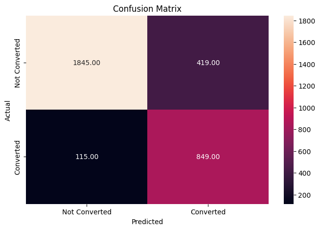

```
Performance on Test Set:
              precision    recall  f1-score   support

           0       0.93      0.81      0.87       971
           1       0.66      0.87      0.75       413

    accuracy                           0.83      1384
   macro avg       0.80      0.84      0.81      1384
weighted avg       0.85      0.83      0.83      1384
```

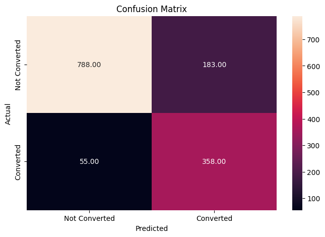

```python
# Evaluate model on training data
print("\nPerformance on Training Set:")
y_train_pred = dt.predict(X_train)
metrics_score(y_train, y_train_pred)

# Evaluate model on test data
print("\nPerformance on Test Set:")
y_test_pred = dt.predict(X_test)
metrics_score(y_test, y_test_pred)
```

```python
# Model performance metrics
dt_test_perf = model_performance_classification(dt, X_test, y_test)
print("\nModel Performance Metrics:")
dt_test_perf
```

```
Model Performance Metrics:
```

|  | Precision | Recall | Accuracy |
| --- | --- | --- | --- |
| 0 | 0.798247 | 0.839181 | 0.828035 |

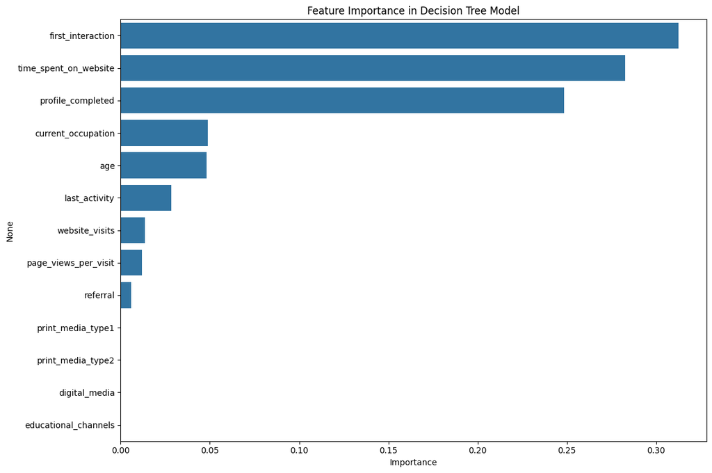

```
Feature Importance:
                       Importance
first_interaction        0.312582
time_spent_on_website    0.282491
profile_completed        0.248403
current_occupation       0.048779
age                      0.048141
last_activity            0.028439
website_visits           0.013507
page_views_per_visit     0.011849
referral                 0.005810
print_media_type1        0.000000
print_media_type2        0.000000
digital_media            0.000000
educational_channels     0.000000
```

```python
# Plot feature importance
importances = dt.feature_importances_
columns = X.columns
importance_df = pd.DataFrame(importances, index=columns,
                            columns=['Importance']).sort_values(by='Importance',
                                                             ascending=False)

plt.figure(figsize=(12, 8))
sns.barplot(x=importance_df.Importance, y=importance_df.index)
plt.title('Feature Importance in Decision Tree Model')
plt.tight_layout()
plt.show()

print("\nFeature Importance:")
print(importance_df)
```

#### Observation:

- **Training vs Test Performance**: The basic decision tree shows fairly consistent performance between training and testing datasets. Training achieved a 83% accuracy, F1-scores of 0.87 (class 0) and 0.76 (class 1) while testing achieved a 83% accuracy, F1-scores of 0.87 (class 0) and 0.75 (class 1). This consistency indicates good generalization without overfitting, likely due to the max_depth=5 parameter that effectively constrained the model.
- **Confusion Matrix Insights**: From the training set we saw 1845 true negatives, 849 true positives, with 419 false positives and 115 false negatives and from the testing set we saw 788 true negatives, 358 true positives, with 183 false positives and 55 false negatives. This model has a higher false positive rate than false negative rate, suggesting it's slightly biased toward predicting conversions.
- **Feature Importance**: Three features dominate the model's decisions (1) first_interaction (31.2%), (2) time_spent_on_website (28.2%) and (3) profile_completed (24.8%). Together these account for over 84% of the decision-making weight, suggesting user engagement metrics are highly predictive of conversion. Several features have zero importance (print_media, digital_media, educational_channels), indicating they could potentially be removed to simplify the model.

```python
dtree_estimator = DecisionTreeClassifier(class_weight=class_weights, random_state=42)

# Grid of parameters to choose from
parameters = {'max_depth': np.arange(2, 7),
              'criterion': ['gini', 'entropy'],
              'min_samples_leaf': [5, 10, 20, 25]
             }

# Type of scoring used to compare parameter combinations
scorer = metrics.make_scorer(recall_score, pos_label=1)

print("\nPerforming grid search for hyperparameter tuning...")
# Run the grid search with 5-fold cross-validation
gridCV = GridSearchCV(dtree_estimator, parameters, scoring=scorer, cv=5, n_jobs=-1)

# Fit the grid search on the training data
gridCV = gridCV.fit(X_train, y_train)

# Print the best parameters and best score
print("\nBest parameters found by grid search:")
print(gridCV.best_params_)
print(f"Best cross-validation score: {gridCV.best_score_:.4f}")

# Set the classifier to the best combination of parameters
optimized_dt = gridCV.best_estimator_

# Print the tree structure details
print("\nOptimized Decision Tree Structure:")
print(f"Tree depth: {optimized_dt.get_depth()}")
print(f"Number of leaves: {optimized_dt.get_n_leaves()}")
print(f"Selected criterion: {optimized_dt.criterion}")
print(f"Min samples leaf: {optimized_dt.min_samples_leaf}")
```

```
Performing grid search for hyperparameter tuning...

Best parameters found by grid search:
{'criterion': 'entropy', 'max_depth': np.int64(3), 'min_samples_leaf': 5}
Best cross-validation score: 0.8828

Optimized Decision Tree Structure:
Tree depth: 3
Number of leaves: 8
Selected criterion: entropy
Min samples leaf: 5
```

```
Performance of Optimized Model on Training Set:
              precision    recall  f1-score   support

           0       0.95      0.74      0.83      2264
           1       0.60      0.90      0.72       964

    accuracy                           0.79      3228
   macro avg       0.77      0.82      0.78      3228
weighted avg       0.84      0.79      0.80      3228
```

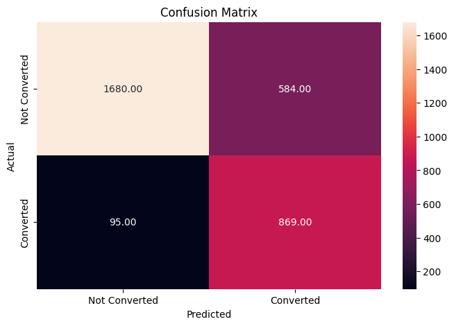

```
Performance of Optimized Model on Test Set:
              precision    recall  f1-score   support

           0       0.95      0.74      0.83       971
           1       0.60      0.90      0.72       413

    accuracy                           0.79      1384
   macro avg       0.77      0.82      0.77      1384
weighted avg       0.84      0.79      0.80      1384
```

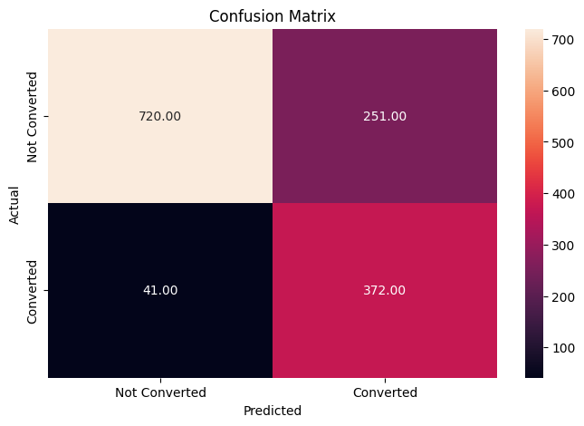

```python
# Evaluate optimized model on training data
print("\nPerformance of Optimized Model on Training Set:")
y_train_pred_opt = optimized_dt.predict(X_train)
metrics_score(y_train, y_train_pred_opt)

# Evaluate optimized model on test data
print("\nPerformance of Optimized Model on Test Set:")
y_test_pred_opt = optimized_dt.predict(X_test)
metrics_score(y_test, y_test_pred_opt)
```

```python
# Model performance metrics for optimized model
optimized_dt_test_perf = model_performance_classification(optimized_dt, X_test, y_test)
print("\nOptimized Model Performance Metrics:")
print(optimized_dt_test_perf)
```

```
Optimized Model Performance Metrics:
   Precision    Recall  Accuracy
0   0.771617  0.821115  0.789017
```

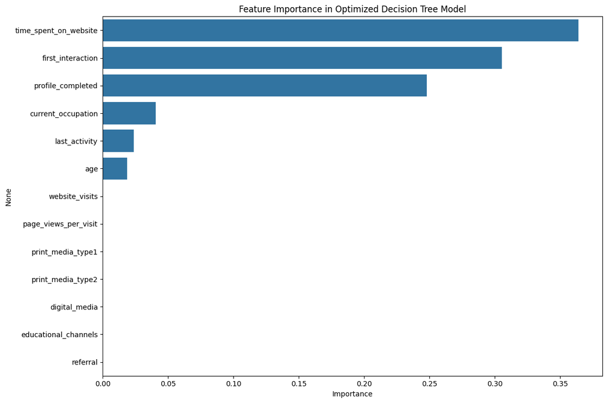

```
Feature Importance for Optimized Model:
                       Importance
time_spent_on_website    0.364159
first_interaction        0.305198
profile_completed        0.247771
current_occupation       0.040569
last_activity            0.023661
age                      0.018641
website_visits           0.000000
page_views_per_visit     0.000000
print_media_type1        0.000000
print_media_type2        0.000000
digital_media            0.000000
educational_channels     0.000000
referral                 0.000000
```

```python
# Plot feature importance for optimized model
optimized_importances = optimized_dt.feature_importances_
optimized_importance_df = pd.DataFrame(optimized_importances, index=columns,
                            columns=['Importance']).sort_values(by='Importance',
                                                             ascending=False)

plt.figure(figsize=(12, 8))
sns.barplot(x=optimized_importance_df.Importance, y=optimized_importance_df.index)
plt.title('Feature Importance in Optimized Decision Tree Model')
plt.tight_layout()
plt.show()

print("\nFeature Importance for Optimized Model:")
print(optimized_importance_df)
```